# Flowering Milkweed Distribution Models

Keaton Wilson

7/11/2019

## Introduction

Recent work has generated habitat suitability models for Monarchs in the West, which appears to be structured primarily by host plant habitat associations, which are driven by climatic variables (Dilts et al. 2019).

This paper lays the groundwork for using the accessible [Milkweed Mapper](https://www.monarchmilkweedmapper.org) data to create predictive models of where Monarchs are on the landscape in the west, where their associated host plants are, and make inferences about environmental variables affecting this relationship.

The goal of this preliminary work is to explore these data with a few a specific aims:

1. Explore a subset of the Milkweed Mapper data: **records of flowering Milkweeds**
2. Determine temporal and spatial patterns of floral resources
3. Develop a mixed-species distribution model(s) that focuses on early, mid, and late blooming milkweed
4. Examine how these patterns have changed over time (given that there is enough data)

## Data Access and Summary

I manually downloaded the data from the [export page](https://www.monarchmilkweedmapper.org/app/#/combined/map) on the Western Monarch Milkweed mapper website. I filtered for all milkweed species, and only records of flowering plants. Data was accessed at July 8th, 2019.

I also did a bit of preprocessing on the data that I won’t show here. Added a few useful new columns like the full scientific name, the mean month that a given species is flowering, and then breaking each species into an early, mid or late bloomer where:

**early bloomer <= 6.5 as average month (mid June)**  
**late bloomer <= 7.5 as average month (mid July)**  
**mid bloomer = everything in between**

The figure below shows the distribution of occurence records of flowering examples for each of the species, with the median as a vertical line.

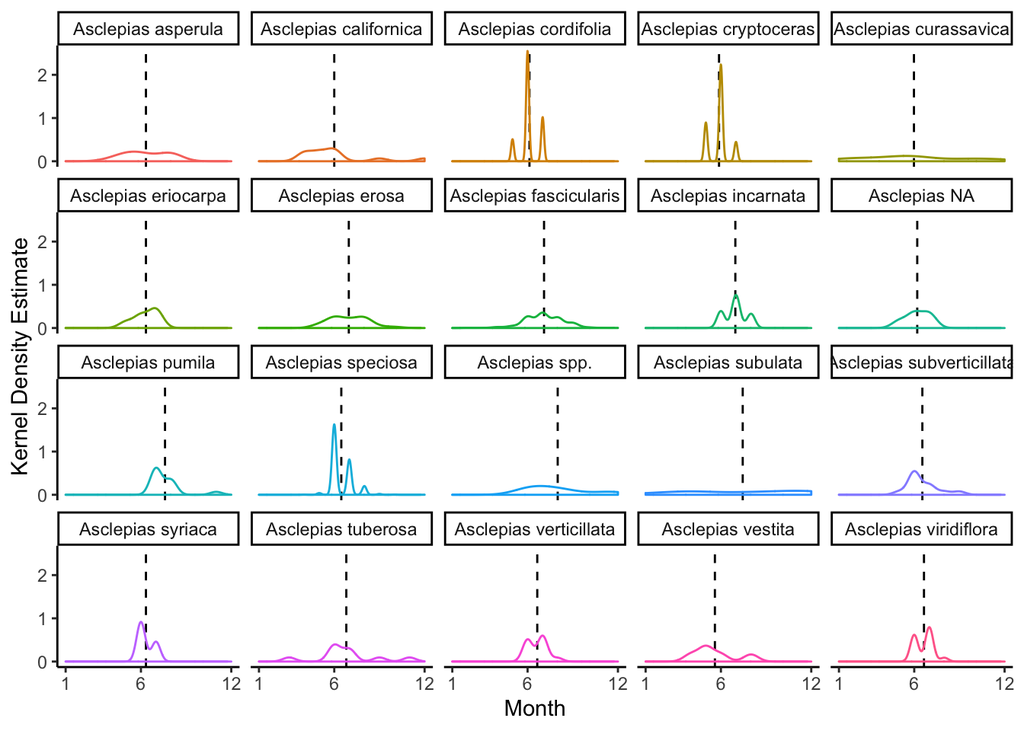

Overall, there were 2038 records for early bloomers (10 species, including those with no species description), 482 records for mid (8 species) and 25 for late (2 species, including a generalized category spp.). I also removed species from the data set with very low record numbers (< 5).

Let’s look quickly at a summary of the processed data frame:

```
## Observations: 2,545
## Variables: 13
## $ name              <chr> "Asclepias asperula", "Asclepias asperula", "A…
## $ mean_month        <dbl> 6.333333, 6.333333, 6.333333, 6.333333, 6.3333…
## $ flowering_cat     <fct> early, early, early, early, early, early, earl…
## $ Genus             <chr> "Asclepias", "Asclepias", "Asclepias", "Asclep…
## $ SpeciesSubSpecies <chr> "asperula", "asperula", "asperula", "asperula"…
## $ latitude          <dbl> 32.30088, 36.26271, 36.26339, 36.26419, 36.161…
## $ longitude         <dbl> -106.5994, -115.6101, -115.6118, -115.6111, -1…
## $ HabitatType       <chr> "Desert", NA, NA, NA, NA, NA, NA, NA, "Riparia…
## $ State             <chr> "New Mexico", "Nevada", "Nevada", "Nevada", "N…
## $ County            <chr> "Doña Ana", "Clark", "Clark", "Clark", "Clark"…
## $ RecordYear        <dbl> 2019, 2016, 2016, 2016, 2016, 2016, 2016, 2016…
## $ DateIdentified    <date> 2019-05-02, 2016-08-25, 2016-08-25, 2016-08-2…
## $ quarter           <dbl> 2, 3, 3, 3, 3, 2, 2, 2, 2, 2, 2, 3, 2, 2, 2, 2…
```

## Preliminary Mapping

As a first pass, let’s take a look at a map of all of our records, color-coded by the different flowering categories (early, mid, late).

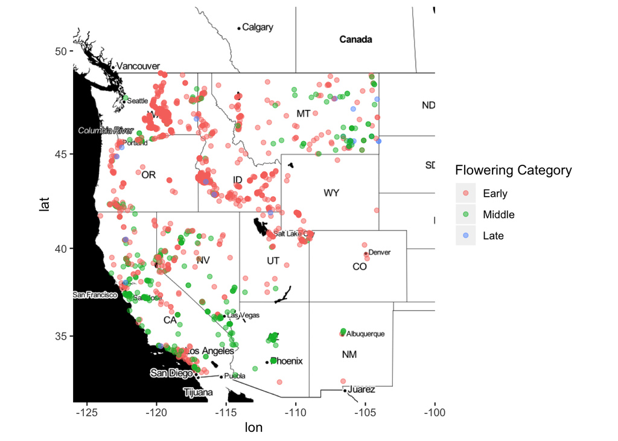